# NPRB - Hogan Bay Exploratory Analysis

# Introduction

This is a quick exploratory analysis of the NPRB Hogan Bay 2013-2016 genotype data. Here we will:

- Create *LocusControl*
- Read in all project genotypes
- Read in paired field/otoltih data from [OceanAK](http://www.oceanak.adfg.alaska.gov/)
- Join paired data from OceanAK
  - Will need to create data key for join (DWP barcode + “_" + DWP position number)
- Determine *FailureRate*
- Perform QA on project gentoypes
  - Removing fish missing >= 20% of genotypes
  - Remove within collection duplicates
  - Explore the use of a **heterozygosity** filter to remove individuals with bogus genotype calls
  - Save final, post-QA genotypes with paired data
- Explore genetic structure
  - Among brood lines (even/odd)
  - Among years
  - Among hatchery/wild (note different hatcheries have different brood sources)
- Export genotypes as a *Genepop* file to feed in to *genepop2franz.GCL.r*

# Read in genotypes

Create *LocusControl* and read in genotypes by *silly*

```r
sillyvec <- ProjectSillys <- c("PHOGAN13", "PHOGAN14", "PHOGAN15", "PHOGAN16")
markersuite <- "Pink_PWS_304"

CreateLocusControl.GCL(markersuite = markersuite, username = .username, password = .password)
loci <- LocusControl$locusnames
nalleles <- LocusControl$nalleles
ploidy <- LocusControl$ploidy
alleles <- LocusControl$alleles

LOKI2R.GCL(sillyvec = sillyvec, username = .username, password = .password)
rm(.username, .password)
```

Save objects

```r
save_objects(objects = c("LocusControl", "loci", "sillyvec", "ProjectSillys"), path = "../Objects")
save_sillys(sillyvec = sillyvec, path = "../Genotypes/Original/")
```

# OceanAK

## Read data

Read in paired field and otolith data from *OceanAK*, join that data to the attributes table of each silly object.

```r
AHRP_oceanak <- read_csv("v:/Analysis/5_Coastwide/Multispecies/Alaska Hatchery Research Program/PWS Pink/OceanAK/AHRP - Salmon Biological Data 2_PWS_2013-2017_no_otoliths.csv")
hogan_oceanak <- AHRP_oceanak %>%
  dplyr::filter(`Location Code` == "Hogan Creek") %>%
  tidyr::unite(silly_source, c("Silly Code", "Fish ID"), sep = "_", remove = FALSE)
```

## Join attributes table

Join *hogan_oceanak* data to the attributes table of each silly. Already looked to verify that no tissues were missing or duplicated, this makes sense because the lab can’t genotype tissue that aren’t there and they never genotype two samples in a well.

```r
PHOGAN13.gcl$attributes <- PHOGAN13.gcl$attributes %>%
  dplyr::left_join(hogan_oceanak, by = c("SillySource" = "silly_source")) %>%
  dplyr::select(FK_FISH_ID, SILLY_CODE, PLATE_ID, DNA_TRAY_CODE, DNA_TRAY_WELL_CODE, SillySource, `Sample Date`, Sex, `Length Mm`, `Location Code`, `Otolith Mark Present`, `Otolith Mark ID`, `Sample Year`)
```

[output not shown]

## Split by otolith-origin

First we need to verify that we only have hatcery and natural-origin fish for the **F0** years (2013 & 2014), and only natural-origin fish for the **F1** years (2015 & 2016).

```r
dplyr::bind_rows(PHOGAN13.gcl$attributes,
                 PHOGAN14.gcl$attributes,
                 PHOGAN15.gcl$attributes,
                 PHOGAN16.gcl$attributes) %>%
  count(SILLY_CODE, `Otolith Mark Present`) %>%
  spread(`Otolith Mark Present`, n, fill = 0)
```

```r
PHOGAN15_ids_remove <- PHOGAN15.gcl$attributes %>%
  filter(`Otolith Mark Present` == "YES" | is.na(`Otolith Mark Present`)) %>%
  mutate(FK_FISH_ID = as.character(FK_FISH_ID)) %>%
  pull(FK_FISH_ID)
RemoveIDs.GCL(silly = "PHOGAN15", IDs = PHOGAN15_ids_remove)
```

Now that we have removed those fish that we did not want due to their otolith status, we will split 2013 & 2014 by otolith-origin. Also create a new *sillyvec*.

```r
PHOGAN13_ids_natural <- list("PHOGAN13" = PHOGAN13.gcl$attributes %>%
  filter(`Otolith Mark Present` == "NO") %>%
  mutate(FK_FISH_ID = as.character(FK_FISH_ID)) %>%
  pull(FK_FISH_ID))
PoolCollections.GCL(collections = "PHOGAN13", loci = loci, IDs = PHOGAN13_ids_natural, newname = "PHOGAN13n")

PHOGAN13_ids_hatchery <- list("PHOGAN13" = PHOGAN13.gcl$attributes %>%
  filter(`Otolith Mark Present` == "YES") %>%
  mutate(FK_FISH_ID = as.character(FK_FISH_ID)) %>%
  pull(FK_FISH_ID))
PoolCollections.GCL(collections = "PHOGAN13", loci = loci, IDs = PHOGAN13_ids_hatchery, newname = "PHOGAN13h")

PHOGAN14_ids_natural <- list("PHOGAN14" = PHOGAN14.gcl$attributes %>%
  filter(`Otolith Mark Present` == "NO") %>%
  mutate(FK_FISH_ID = as.character(FK_FISH_ID)) %>%
  pull(FK_FISH_ID))
PoolCollections.GCL(collections = "PHOGAN14", loci = loci, IDs = PHOGAN14_ids_natural, newname = "PHOGAN14n")

PHOGAN14_ids_hatchery <- list("PHOGAN14" = PHOGAN14.gcl$attributes %>%
  filter(`Otolith Mark Present` == "YES") %>%
  mutate(FK_FISH_ID = as.character(FK_FISH_ID)) %>%
  pull(FK_FISH_ID))
PoolCollections.GCL(collections = "PHOGAN14", loci = loci, IDs = PHOGAN14_ids_hatchery, newname = "PHOGAN14h")

ProjectSillys_Origin <- c("PHOGAN13n", "PHOGAN13h", "PHOGAN14n", "PHOGAN14h", "PHOGAN15", "PHOGAN16")
save_sillys(ProjectSillys_Origin, "../Genotypes/OceanAK_Origin/")
```

# Failure rate

Calculate and view the failure rate by silly, locus, and plate.

```r
project <- "NPRB"
failure_rate <- FailureRate.GCL(sillyvec = ProjectSillys_Origin)
failure_rate_noplots <- failure_rate[1:4]
save_objects("failure_rate_noplots", "../Objects/")
failure_rate
```

# QA

Go through our standard Quality Assurance (QA) process, then explore heterozygosity. Produce a matrix with sample sizes.

```r
ProjectSillys_Origin_SampleSizes <- matrix(data = NA, nrow = length(ProjectSillys_Origin), ncol = 5, dimnames = list(ProjectSillys_Origin, c("Genotyped", "Missing", "Duplicate", "Heterozygosity", "Final")))
ProjectSillys_Origin_SampleSizes[, "Genotyped"] <- sapply(paste0(ProjectSillys_Origin, ".gcl"), function(x) get(x)$n)
```

## Missing

Remove individuals missing >=20% of genotypes (i.e. the 80% rule).

```r
MissLoci <- RemoveIndMissLoci.GCL(sillyvec = ProjectSillys_Origin, proportion = 0.8)
MissLoci  # character vector of fish removed
save_objects("MissLoci", path = "../Objects/")
ProjectSillys_Origin_SampleSizes[, "Missing"] <-  ProjectSillys_Origin_SampleSizes[, "Genotyped"] - sapply(paste0(ProjectSillys_Origin, ".gcl"), function(x) get(x)$n)
```

## Duplicate

Remove duplicate individuals within the same collection. Typically we specify *duplicates* as a pair of individuals that share >=95% of genotypes. Once a pair of *duplicates* is identified, we keep the individual with the most genotypes and remove the other.

```r
DuplicateCheck95MinProportion <- CheckDupWithinSilly.GCL(sillyvec = ProjectSillys_Origin, loci = loci, quantile = NULL, minproportion = 0.95)
DuplicateCheckReportSummary <- sapply(ProjectSillys_Origin, function(x) DuplicateCheck95MinProportion[[x]]$report, simplify = FALSE)
DuplicateCheckReportSummary
save_objects("DuplicateCheckReportSummary", path = "../Objects/")
```

```r
#RemovedDups <- RemoveDups.GCL(DuplicateCheck95MinProportion)
#save_objects("RemovedDups", path = "../Objects/")

# All duplicate IDs in to one tibble
dups <- bind_rows(DuplicateCheckReportSummary[sapply(DuplicateCheckReportSummary, is.data.frame)], .id = "silly") %>%
  select(silly, ID1, ID2) %>%
  gather(trash, id, -silly) %>%
  select(-trash) %>%
  arrange(silly, id)

# Separate vector of IDs for each silly
dup_13h_ids <- filter(dups, silly == "PHOGAN13h") %>% pull(id)
dup_14h_ids <- filter(dups, silly == "PHOGAN14h") %>% pull(id)
dup_15_ids <- filter(dups, silly == "PHOGAN15") %>% pull(id)
dup_16_ids <- filter(dups, silly == "PHOGAN16") %>% pull(id)


# ID silly sources for duplicate individuals
dup_13h <- PHOGAN13h.gcl$attributes %>%
  filter(FK_FISH_ID %in% dup_13h_ids) %>%
  mutate(FK_FISH_ID = as.numeric(FK_FISH_ID))
dup_14h <- PHOGAN14h.gcl$attributes %>%
  filter(FK_FISH_ID %in% dup_14h_ids) %>%
  mutate(FK_FISH_ID = as.numeric(FK_FISH_ID))
dup15 <- PHOGAN15.gcl$attributes %>%
  filter(FK_FISH_ID %in% dup_15_ids)
dup16 <- PHOGAN16.gcl$attributes %>%
  filter(FK_FISH_ID %in% dup_16_ids)

# One tibble with all attributes for fish to remove
duplicates_to_remove <- bind_rows(dup_14h, dup_13h, dup15, dup16)
save_objects("duplicates_to_remove", path = "../Objects/")

# Remove fish from .gcl objects
RemoveIDs.GCL(silly = "PHOGAN13h", IDs = dup_13h_ids)
RemoveIDs.GCL(silly = "PHOGAN14h", IDs = dup_14h_ids)
RemoveIDs.GCL(silly = "PHOGAN15", IDs = dup_15_ids)
RemoveIDs.GCL(silly = "PHOGAN16", IDs = dup_16_ids)

# Fill in sample size matrix
ProjectSillys_Origin_SampleSizes[, "Duplicate"] <-  ProjectSillys_Origin_SampleSizes[, "Genotyped"] - ProjectSillys_Origin_SampleSizes[, "Missing"] - sapply(paste0(ProjectSillys_Origin, ".gcl"), function(x) get(x)$n)
```

## Heterozygosity

We know from the QC work that the **GTscore** genotyping pipeline can sometimes result in individuals with an overabundance of heterozygous calls (perhaps from contamination?). We want to remove individuals with untrustworth genotypes. In order to explore the utility of some sort of *heterozygosity filter*, we should first plot a histogram of heterozygosity per individual to see what the problem looks like. From there we can set a threshold or range of acceptable heterozygosities.

```r
#genotype.counts <- apply(PHOGAN13.gcl$scores, MARGIN=1, table) #provides counts of each genotype/individual
#calculate heterozygosity by individual :-)
PHOGAN13n_ind_het <- apply(PHOGAN13n.gcl$scores, 1, function(ind) {sum(ind[ ,"Dose1"] != ind[ ,"Dose2"])/304} )
PHOGAN13h_ind_het <- apply(PHOGAN13h.gcl$scores, 1, function(ind) {sum(ind[ ,"Dose1"] != ind[ ,"Dose2"])/304} )
PHOGAN14n_ind_het <- apply(PHOGAN14n.gcl$scores, 1, function(ind) {sum(ind[ ,"Dose1"] != ind[ ,"Dose2"])/304} )
PHOGAN14h_ind_het <- apply(PHOGAN14h.gcl$scores, 1, function(ind) {sum(ind[ ,"Dose1"] != ind[ ,"Dose2"])/304} )
PHOGAN15_ind_het <- apply(PHOGAN15.gcl$scores, 1, function(ind) {sum(ind[ ,"Dose1"] != ind[ ,"Dose2"])/304} )
PHOGAN16_ind_het <- apply(PHOGAN16.gcl$scores, 1, function(ind) {sum(ind[ ,"Dose1"] != ind[ ,"Dose2"])/304} )
```

### Plot by silly

Plot with *tidyverse* for ease of use/visualization. Add +- 3SD cutoff from literature (Anderson et al. 2010).

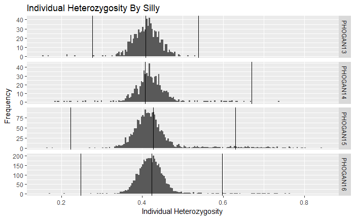

```r
# Convert to tibbles
tibble_PHOGAN13n <- tibble(silly=PHOGAN13n.gcl$attributes$SILLY_CODE, sillysource=PHOGAN13n.gcl$attributes$SillySource, het=PHOGAN13n_ind_het)
tibble_PHOGAN13h <- tibble(silly=PHOGAN13h.gcl$attributes$SILLY_CODE, sillysource=PHOGAN13h.gcl$attributes$SillySource, het=PHOGAN13h_ind_het)
tibble_PHOGAN14n <- tibble(silly=PHOGAN14n.gcl$attributes$SILLY_CODE, sillysource=PHOGAN14n.gcl$attributes$SillySource, het=PHOGAN14n_ind_het)
tibble_PHOGAN14h <- tibble(silly=PHOGAN14h.gcl$attributes$SILLY_CODE, sillysource=PHOGAN14h.gcl$attributes$SillySource, het=PHOGAN14h_ind_het)
tibble_PHOGAN15 <- tibble(silly=PHOGAN15.gcl$attributes$SILLY_CODE, sillysource=PHOGAN15.gcl$attributes$SillySource, het=PHOGAN15_ind_het)
tibble_PHOGAN16 <- tibble(silly=PHOGAN16.gcl$attributes$SILLY_CODE, sillysource=PHOGAN16.gcl$attributes$SillySource, het=PHOGAN16_ind_het)
# Create a single tibble
het_tibble <- bind_rows(tibble_PHOGAN13n, tibble_PHOGAN13h, tibble_PHOGAN14n, tibble_PHOGAN14h, tibble_PHOGAN15, tibble_PHOGAN16)

#make het mean and lower and upper bounds (+/-3SD) tibbles
mean_het <- het_tibble %>%
  dplyr::group_by(silly) %>%
  dplyr::summarise(het=mean(het))
low_cutoff_het <- het_tibble %>%
  dplyr::group_by(silly) %>%
  summarise(het=mean(het)-3*sd(het))
high_cutoff_het <- het_tibble %>%
  dplyr::group_by(silly) %>%
  summarise(het=mean(het)+3*sd(het))
#plot individual heterozygosity by silly:
het_tibble %>%
    ggplot2::ggplot(aes(x = het)) +
    ggplot2::geom_histogram(binwidth = 1/304) +
    ggplot2::geom_vline(aes(xintercept = het), mean_het) +
    ggplot2::geom_vline(aes(xintercept = het), low_cutoff_het) +
    ggplot2::geom_vline(aes(xintercept = het), high_cutoff_het) +
    ggplot2::facet_grid(rows=vars(silly), scales = "free_y") +
    ggplot2::xlim(0.15, 0.85) +
    ggplot2::xlab("Individual Heterozygosity") +
    ggplot2::ylab("Frequency") +
    ggplot2::ggtitle("Individual Heterozygosity By Silly")
```

After discussions with Chris, Tyler, and Dan, we decided that it would be more appropriate to examine heterozygosity by lineage (even versus odd) instead of year. Additionally, we all agreed that the +-3SD cutoff was not restrictive enough, the upper bound for the cutoff should be closer to the main distribution.

### Plot by lineage

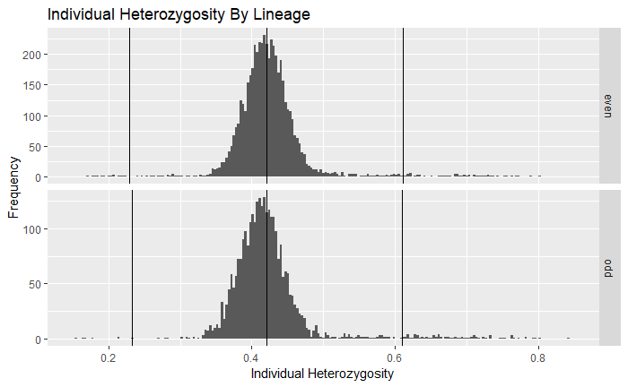

```r
#combine tibbles and add lineage as grouping variable
het_tibble <- het_tibble %>%
  dplyr::mutate(lineage = dplyr::case_when(silly %in% c("PHOGAN13", "PHOGAN15") ~ "odd",
                           silly %in% c("PHOGAN14", "PHOGAN16") ~ "even"))
save_objects("het_tibble", "../Objects/")
#make het mean and lower and upper bounds (+/-3SD) tibbles
mean_het <- het_tibble %>%
  dplyr::group_by(lineage) %>%
  dplyr::summarise(het=mean(het))
low_cutoff_het <- het_tibble %>%
  dplyr::group_by(lineage) %>%
  summarise(het=mean(het)-3*sd(het))
high_cutoff_het <- het_tibble %>%
  dplyr::group_by(lineage) %>%
  summarise(het=mean(het)+3*sd(het))
#plot individual heterozygosity by lineage:
het_tibble %>%
    ggplot2::ggplot(aes(x = het)) +
    ggplot2::geom_histogram(binwidth = 1/304) +
    ggplot2::geom_vline(aes(xintercept = het), mean_het) +
    ggplot2::geom_vline(aes(xintercept = het), low_cutoff_het) +
    ggplot2::geom_vline(aes(xintercept = het), high_cutoff_het) +
    ggplot2::facet_grid(rows=vars(lineage), scales = "free_y") +
    ggplot2::xlim(0.15, 0.85) +
    ggplot2::xlab("Individual Heterozygosity") +
    ggplot2::ylab("Frequency") +
    ggplot2::ggtitle("Individual Heterozygosity By Lineage")
```

How many fish would we lose if we went with these cutoffs?

```r
# Upper cutoff only, lower doesn't apply
het_tibble %>%
  dplyr::group_by(lineage) %>%
  dplyr::summarise(upper = mean(het) + 3* sd(het)) %>%
  dplyr::right_join(het_tibble) %>%
  dplyr::filter(het >= upper) %>%
  dplyr::count(lineage)
```

| lineage | n |
| --- | --- |
| even | 79 |
| odd | 79 |

### Cutoffs to remove outliers

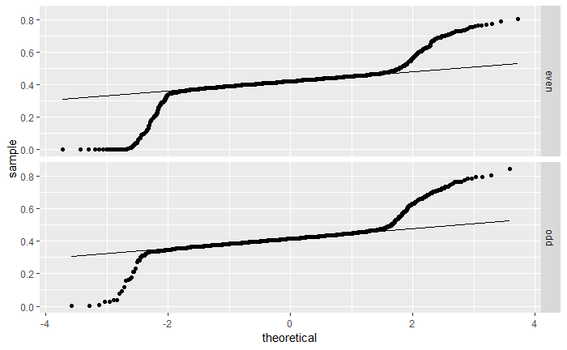

```r
#qq plot of heterozygosity by lineage:
het_tibble %>%
    ggplot2::ggplot(aes(sample = het)) +
    ggplot2::stat_qq() +
    ggplot2::stat_qq_line() +
    ggplot2::facet_grid(rows = vars(lineage)) #+
```

```r
    #ggplot2::coord_flip()
```

Same idea, but with a boxplot. **Note** all points are 1.5 IQR +- upper/lower boxplot. Perhaps we could use this 1.5 IQR approach for removing outliers?

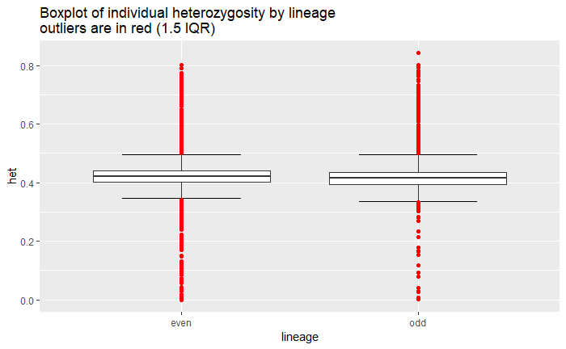

```r
het_tibble %>%
  ggplot2::ggplot(aes(x = lineage, y = het)) +
  ggplot2::stat_boxplot(geom = "errorbar", width = 0.5) +
  ggplot2::geom_boxplot(outlier.colour = "red", notch = FALSE, varwidth = FALSE, coef = 1.5) +
  ggplot2::ggtitle("Boxplot of individual heterozygosity by lineage\noutliers are in red (1.5 IQR)")
```

```r
# Calculate 1.5 IQR
het_IQR_cutoffs <- het_tibble %>%
  dplyr::group_by(lineage) %>%
  dplyr::summarise(low_1.5_IQR = quantile(het, probs = 0.25) - 1.5 * diff(quantile(het, probs = c(0.25, 0.75))),
            high_1.5_IQR = quantile(het, probs = 0.75) + 1.5 * diff(quantile(het, probs = c(0.25, 0.75))))
```

Chris suggested that we stick with the +-3SD approach, however, before calculating the SD, we mirror the left hand side of the distribution to the right (assuming the **mode** should be the **mean**).

```r
# Calculate mode of each distribution
mode_het <- het_tibble %>%
  dplyr::group_by(lineage) %>%
  dplyr::count(het) %>%
  dplyr::slice(which.max(n))


# Chris wants to assume the mode is the mean, mirror the lower half of the dist, calculate SD and use that for +-3SD
# Odd mirror lower bounds +-3sd
het_tibble %>%
  dplyr::filter(lineage == "odd", het < 0.4078947) %>%
  dplyr::mutate(het = 0.4078947 - het + 0.4078947) %>%
  dplyr::bind_rows(het_tibble %>%
              filter(lineage == "odd", het <= 0.4078948)  # floating point error
           ) %>%
  # ggplot(aes(x = het)) +
  # geom_histogram(binwidth = 1/304)
  dplyr::group_by(lineage) %>%
  dplyr::summarise(het_mean = mean(het),
            het_lower_3sd = mean(het) - 3 * sd(het),
            het_upper_3sd = mean(het) + 3 * sd(het))


# Even mirror lower bounds +-3sd
het_tibble %>%
  dplyr::filter(lineage == "even", het < 0.4177631) %>%
  dplyr::mutate(het = 0.4177631 - het + 0.4177631) %>%
  dplyr::bind_rows(het_tibble %>%
              filter(lineage == "even", het <= 0.4177633)  # floating point error
  ) %>%
  # ggplot(aes(x = het)) +
  # geom_histogram(binwidth = 1/304)
  dplyr::group_by(lineage) %>%
  dplyr::summarise(het_mean = mean(het),
            het_lower_3sd = mean(het) - 3 * sd(het),
            het_upper_3sd = mean(het) + 3 * sd(het))
```

Now lets look at all three of these approaches on the original histograms.

1. +-3SD by lineage
2. 1.5 IQR +- 75% and 25% quartiles
3. Chris’ +-3SD by lineage only using the left hand side of the distribution.

```r
mean_het <- het_tibble %>%
  dplyr::group_by(lineage) %>%
  dplyr::summarise(het=mean(het))

low_cutoff_het <- het_tibble %>%
  dplyr::group_by(lineage) %>%
  dplyr::summarise(het=mean(het)-3*sd(het))

high_cutoff_het <- het_tibble %>%
  dplyr::group_by(lineage) %>%
  dplyr::summarise(het=mean(het)+3*sd(het))

low_box_het <- het_tibble %>%
  dplyr::group_by(lineage) %>%
  dplyr::summarise(het = quantile(het, probs = 0.25) - 1.5 * diff(quantile(het, probs = c(0.25, 0.75))))

high_box_het <- het_tibble %>%
  dplyr::group_by(lineage) %>%
  dplyr::summarise(het = quantile(het, probs = 0.75) + 1.5 * diff(quantile(het, probs = c(0.25, 0.75))))

odd_chris_het <- het_tibble %>%
  dplyr::filter(lineage == "odd", het < 0.4078947) %>%
  dplyr::mutate(het = 0.4078947 - het + 0.4078947) %>%
  dplyr::bind_rows(het_tibble %>%
              filter(lineage == "odd", het <= 0.4078948)  # floating point error
           ) %>%
  dplyr::group_by(lineage) %>%
  dplyr::summarise(het_mean = mean(het),
            het_lower_3sd = mean(het) - 3 * sd(het),
            het_upper_3sd = mean(het) + 3 * sd(het))

even_chris_het <-
  het_tibble %>%
  dplyr::filter(lineage == "even", het < 0.4177631) %>%
  dplyr::mutate(het = 0.4177631 - het + 0.4177631) %>%
  dplyr::bind_rows(het_tibble %>%
              filter(lineage == "even", het <= 0.4177633)  # floating point error
  ) %>%
  dplyr::group_by(lineage) %>%
  dplyr::summarise(het_mean = mean(het),
            het_lower_3sd = mean(het) - 3 * sd(het),
            het_upper_3sd = mean(het) + 3 * sd(het))

chris_het_tibble <- dplyr::bind_rows(odd_chris_het, even_chris_het)

low_chris_het <- tibble(lineage=chris_het_tibble$lineage, het=chris_het_tibble$het_lower_3sd)

high_chris_het <- tibble(lineage=chris_het_tibble$lineage, het=chris_het_tibble$het_upper_3sd)

het_tibble %>%
  ggplot2::ggplot(aes(x = het)) +
  ggplot2::geom_histogram(binwidth = 1/304) +
  ggplot2::geom_vline(aes(xintercept = het, color = "mean"), mean_het) +
  ggplot2::geom_vline(aes(xintercept = het, color = "SD"), low_cutoff_het) +
  ggplot2::geom_vline(aes(xintercept = het, color = "SD"), high_cutoff_het) +
  ggplot2::geom_vline(aes(xintercept = het, color = "IQR"), low_box_het) +
  ggplot2::geom_vline(aes(xintercept = het, color = "IQR"), high_box_het) +
  ggplot2::geom_vline(aes(xintercept = het, color = "Chris"), low_chris_het) +
  ggplot2::geom_vline(aes(xintercept = het, color = "Chris"), high_chris_het) +
  ggplot2::facet_grid(rows=vars(lineage), scales = "free_y") +
  ggplot2::scale_color_manual(name="statistics", values=c(mean="blue", SD="red", IQR="black", Chris="orange")) +
  ggplot2::xlim(0.15, 0.85) +
  ggplot2::xlab("Individual Heterozygosity") +
  ggplot2::ylab("Frequency") +
  ggplot2::ggtitle("Individual Heterozygosity By Lineage")
```

[output not shown]

### Remove fish with IQR cutoff

```r
# Get list of fish to remove
het_tibble %>%
  dplyr::left_join(het_IQR_cutoffs, by = "lineage") %>%
  dplyr::filter(het < low_1.5_IQR | het > high_1.5_IQR) %>%
  dplyr::count(silly)
```

Now remove those fish. Figure out which ones they are, convert *SillySource* to *FK_FISH_ID* (**note**: the values for *FK_FISH_ID* got reassigned after pooling), remove them.

```r
removed_hets <- het_tibble %>%
  dplyr::left_join(het_IQR_cutoffs, by = "lineage") %>%
  dplyr::filter(het < low_1.5_IQR | het > high_1.5_IQR) %>%
  dplyr::pull(sillysource)
save_objects("removed_hets", "../Objects/")

PHOGAN13h_hets_remove <- PHOGAN13h.gcl$attributes %>%
  dplyr::filter(SillySource %in% removed_hets) %>%
  dplyr::mutate(FK_FISH_ID = as.character(FK_FISH_ID)) %>%
  dplyr::pull(FK_FISH_ID)
RemoveIDs.GCL(silly = "PHOGAN13h", IDs = PHOGAN13h_hets_remove)

PHOGAN13n_hets_remove <- PHOGAN13n.gcl$attributes %>%
  dplyr::filter(SillySource %in% removed_hets) %>%
  dplyr::mutate(FK_FISH_ID = as.character(FK_FISH_ID)) %>%
  dplyr::pull(FK_FISH_ID)
RemoveIDs.GCL(silly = "PHOGAN13n", IDs = PHOGAN13n_hets_remove)

PHOGAN14h_hets_remove <- PHOGAN14h.gcl$attributes %>%
  dplyr::filter(SillySource %in% removed_hets) %>%
  dplyr::mutate(FK_FISH_ID = as.character(FK_FISH_ID)) %>%
  dplyr::pull(FK_FISH_ID)
RemoveIDs.GCL(silly = "PHOGAN14h", IDs = PHOGAN14h_hets_remove)

PHOGAN14n_hets_remove <- PHOGAN14n.gcl$attributes %>%
  dplyr::filter(SillySource %in% removed_hets) %>%
  dplyr::mutate(FK_FISH_ID = as.character(FK_FISH_ID)) %>%
  dplyr::pull(FK_FISH_ID)
RemoveIDs.GCL(silly = "PHOGAN14n", IDs = PHOGAN14n_hets_remove)

PHOGAN15_hets_remove <- PHOGAN15.gcl$attributes %>%
  dplyr::filter(SillySource %in% removed_hets) %>%
  dplyr::mutate(FK_FISH_ID = as.character(FK_FISH_ID)) %>%
  dplyr::pull(FK_FISH_ID)
RemoveIDs.GCL(silly = "PHOGAN15", IDs = PHOGAN15_hets_remove)

PHOGAN16_hets_remove <- PHOGAN16.gcl$attributes %>%
  dplyr::filter(SillySource %in% removed_hets) %>%
  dplyr::mutate(FK_FISH_ID = as.character(FK_FISH_ID)) %>%
  dplyr::pull(FK_FISH_ID)
RemoveIDs.GCL(silly = "PHOGAN16", IDs = PHOGAN16_hets_remove)

ProjectSillys_Origin_SampleSizes[, "Heterozygosity"] <-  ProjectSillys_Origin_SampleSizes[, "Genotyped"] - ProjectSillys_Origin_SampleSizes[, "Missing"] - ProjectSillys_Origin_SampleSizes[, "Duplicate"] - sapply(paste0(ProjectSillys_Origin, ".gcl"), function(x) get(x)$n)
```

## Final

```r
ProjectSillys_Origin_SampleSizes[, "Final"] <- sapply(paste0(ProjectSillys_Origin, ".gcl"), function(x) get(x)$n)
ProjectSillys_Origin_SampleSizes
save_objects("ProjectSillys_Origin_SampleSizes", path = "../Objects/")
```

Save post-QA genotypes.

```r
save_sillys(ProjectSillys_Origin, "../Genotypes/OceanAK_Origin_PostQA/")
```

# Export genepop file

Now that we have final, post QA/QC genotypes, we want to save our work by exporting the genotypes as a **Genepeop** file. That **Genepop** file will then feed in to Chase’s *genepop2franz.GCL.r* script to create a **FRANz** input file for parentage analysis!